# Building Multi-Agent AI System Using LangGraph and LangSmith

Welcome to this comprehensive guide on building **multi-agent workflows** using LangGraph! In this notebook, we'll embark on a journey from a foundational ReAct agent to a sophisticated multi-agent customer support system. We'll explore core LangGraph concepts, leverage its pre-built libraries, and integrate advanced features like human-in-the-loop interactions and long-term memory.

## What is LangGraph?

LangGraph is a library designed to build stateful, multi-actor applications with LLMs, chains, and tools. It extends LangChain by allowing you to define sequences of calls (chains) more robustly, with cycles, conditional logic, and the ability to manage complex state transitions. This makes it ideal for creating agentic workflows where multiple `thinking` and `acting` steps are required, or where different specialized agents need to collaborate.

## Why Multi-Agent?

Multi-agent architectures are powerful for several reasons:

- **Specialization & Modularity**: Instead of a single, monolithic agent trying to handle everything, a multi-agent system comprises smaller, specialized agents. Each agent is optimized for a specific task or domain (e.g., one for music queries, another for invoice details). This improves accuracy and performance within their specialized area.
- **Flexibility & Scalability**: New capabilities can be added by simply integrating a new specialized agent, without needing to retrain or significantly modify existing agents. Agents can be quickly added, removed, or modified, making the system highly adaptable.
- **Robustness**: If one agent fails or performs poorly in its specific task, it doesn't necessarily bring down the entire system, as other agents can still function. This contributes to a more resilient application.
- **Complex Problem Solving**: Many real-world problems require different types of expertise. A multi-agent system can mimic human team collaboration, breaking down complex queries into sub-problems handled by the most appropriate expert agent.

## Our Customer Support Scenario

We will simulate a realistic customer support example for a digital music store. The agent will interact with the [Chinook database](https://www.sqlitetutorial.net/sqlite-sample-database/), which contains comprehensive information about customers, invoices, and a music catalog.

Our final architecture will look something like this:

[figure not shown]

As you can see, the system starts with a **customer verification** step (human-in-the-loop), then **loads user preferences** from long-term memory. A **supervisor agent** then intelligently routes the query to the appropriate specialized sub-agent: either the **music catalog sub-agent** or the **invoice information sub-agent**. Finally, the system **saves any new user preferences** to long-term memory before providing a response.

For a deeper dive into LangGraph primitives and learning our framework, check out our [LangChain Academy](https://academy.langchain.com/courses/intro-to-langgraph)!

## Pre-work: Setup

Before we dive into building our multi-agent system, let's set up our environment. This involves loading necessary environment variables, connecting to our sample database, and initializing our memory stores.

#### Loading Environment Variables

Make sure your `.env` file includes all the keys specified in the `.env.example` file (e.g., `OPENAI_API_KEY`).

```python
from dotenv import load_dotenv # Import function to load environment variables
from langchain_openai import ChatOpenAI # Import the OpenAI chat model

# Load environment variables from the .env file. The `override=True` argument
# ensures that variables from the .env file will overwrite existing environment variables.
load_dotenv(dotenv_path=".env", override=True)

# Initialize the ChatOpenAI model. We're using a specific model from Llama 3.3 series.
# This `model` object will be used throughout the notebook for all LLM interactions.
llm = ChatOpenAI(model_name="meta-llama/Llama-3.3-70B-Instruct", temperature=0)
```

#### Loading Sample Customer Data (Chinook Database)

Our customer support agent will interact with a database to retrieve information. We'll use the [Chinook database](https://www.sqlitetutorial.net/sqlite-sample-database/), a popular sample database that contains tables related to customer information, purchase history, and a music catalog (artists, albums, tracks, genres). This provides a rich dataset for our agent to query.

We'll load this SQLite database into an in-memory database for quick access during the notebook's execution. This avoids persistent file storage and simplifies setup.

```python
import sqlite3 # Standard Python library for SQLite database interaction
import requests # Library for making HTTP requests (to download the SQL script)
from langchain_community.utilities.sql_database import SQLDatabase # LangChain utility to interact with SQL databases
from sqlalchemy import create_engine # SQLAlchemy function to create a database engine
from sqlalchemy.pool import StaticPool # SQLAlchemy connection pool class for in-memory databases

def get_engine_for_chinook_db():
    """Pull sql file, populate in-memory database, and create engine."""
    # URL to the raw SQL script for the Chinook database
    url = "https://raw.githubusercontent.com/lerocha/chinook-database/master/ChinookDatabase/DataSources/Chinook_Sqlite.sql"

    # Fetch the SQL script content from the URL
    response = requests.get(url)
    sql_script = response.text

    # Create an in-memory SQLite database connection.
    # `check_same_thread=False` is important for SQLAlchemy's StaticPool.
    connection = sqlite3.connect(":memory:", check_same_thread=False)

    # Execute the SQL script to populate the in-memory database with Chinook data
    connection.executescript(sql_script)

    # Create a SQLAlchemy engine for the in-memory SQLite database.
    # `creator=lambda: connection` tells SQLAlchemy how to get a new connection.
    # `poolclass=StaticPool` is used for in-memory databases, ensuring the same connection is reused.
    # `connect_args` are passed directly to the `sqlite3.connect` function.
    return create_engine(
        "sqlite://",
        creator=lambda: connection,
        poolclass=StaticPool,
        connect_args={"check_same_thread": False},
    )

# Get the SQLAlchemy engine for our Chinook database
engine = get_engine_for_chinook_db()

# Create a LangChain SQLDatabase utility instance from the engine.
# This utility will help our agents interact with the database via SQL queries.
db = SQLDatabase(engine)
```

#### Setting up Short-Term and Long-Term Memory

Memory is a crucial component for building intelligent agents. LangGraph provides mechanisms to manage both short-term and long-term memory for our workflows.

- **Short-Term Memory (Checkpointer)**: This preserves the state of a specific conversational thread. It allows the agent to maintain context and pick up where it left off within a *single conversation*. If a user's query requires multiple turns or involves human intervention, the checkpointer ensures the graph's state is saved and can be resumed.
  - We use `MemorySaver` for in-memory short-term memory, suitable for demonstration purposes. For production, you'd typically use a persistent checkpointer (e.g., SQL, Redis).
- **Long-Term Memory (InMemoryStore)**: This allows information to be stored and recalled *between conversations* or across different sessions for the same user. In our scenario, we'll use it to store user preferences, enabling personalization. For example, if a user mentions their favorite music genre, this information can be stored and used in future interactions.
  - We use `InMemoryStore` for in-memory long-term storage. Similar to checkpointers, a persistent store (e.g., vector database, key-value store) would be used in a production environment.

```python
from langgraph.checkpoint.memory import MemorySaver # For short-term memory (thread-level state persistence)
from langgraph.store.memory import InMemoryStore # For long-term memory (storing user preferences)

# Initializing `InMemoryStore` for long-term memory.
# This store will hold user-specific data like music preferences across sessions.
in_memory_store = InMemoryStore()

# Initializing `MemorySaver` for short-term (thread-level) memory.
# This checkpointer saves the graph's state after each step, allowing for restarts or interruptions within a thread.
checkpointer = MemorySaver()
```

## Part 1: Building ReAct Sub-Agents

Our multi-agent system will be composed of specialized sub-agents. We'll start by building two foundational ReAct agents, one from scratch to understand the core components, and another using LangGraph's pre-built utilities for quicker development.

### 1.1 Building a ReAct Agent from Scratch: The Music Catalog Sub-Agent

Our first sub-agent will be dedicated to handling customer inquiries related to the music store's catalog. This agent will utilize a set of tools to fetch information about artists, albums, tracks, and genres from the Chinook database.

The ReAct (Reasoning and Acting) framework is a popular pattern for building agents that interleave reasoning steps with acting steps (tool usage). The agent `reasons` about what tool to use and `acts` by calling that tool, then `observes` the result to `reason` again.

[figure not shown]

#### State

In LangGraph, the **State** is a critical concept. It acts as the shared memory of the agent, a data structure that is passed between the nodes of your graph. Each node receives the current state, performs its logic, and returns updates to the state, which then becomes the input for the next node. This continuous flow of information through the state allows the graph to maintain context and build up information as it progresses.

For our customer support agent, the state will track the following key elements:

1. `customer_id`: A string representing the ID of the customer interacting with the agent. This is crucial for personalized queries (e.g., checking invoice history).
2. `messages`: An annotated list of `AnyMessage` objects. This forms the conversation history, including user inputs, agent responses, and tool outputs. `add_messages` ensures that new messages are appended to the list, maintaining the conversational flow.
3. `loaded_memory`: A string that will hold any user preferences or relevant information loaded from the long-term memory store. This allows the agent to tailor responses based on past interactions.
4. `remaining_steps`: A `RemainingSteps` object. This is part of LangGraph's managed state and helps track the number of steps left before a recursion limit is hit, preventing infinite loops in cyclic graphs.

```python
from typing_extensions import TypedDict # For defining dictionaries with type hints
from typing import Annotated, List # For type hinting lists and adding annotations
from langgraph.graph.message import AnyMessage, add_messages # For managing messages in the graph state
from langgraph.managed.is_last_step import RemainingSteps # For tracking recursion limits

class State(TypedDict):
    """Represents the state of our LangGraph agent."""
    # customer_id: Stores the unique identifier for the current customer.
    customer_id: str

    # messages: A list of messages that form the conversation history.
    # Annotated with `add_messages` to ensure new messages are appended rather than overwritten.
    messages: Annotated[list[AnyMessage], add_messages]

    # loaded_memory: Stores information loaded from the long-term memory store,
    # typically user preferences or historical context.
    loaded_memory: str

    # remaining_steps: Used by LangGraph to track the number of allowed steps
    # to prevent infinite loops in cyclic graphs.
    remaining_steps: RemainingSteps
```

#### Tools

Tools are external functionalities that an LLM can invoke to extend its capabilities beyond pure text generation. These can be APIs, database queries, or any arbitrary Python function. In our music catalog sub-agent, we'll define a set of tools that interact with the Chinook database to fetch music-related information.

We use LangChain's `@tool` decorator to easily expose Python functions as tools that our LLM can learn to use. The decorator automatically generates a schema that the LLM can understand, allowing it to determine when and how to call the tool.

```python
from langchain_core.tools import tool # Decorator to define a function as a LangChain tool
import ast # Module to safely evaluate strings containing Python literal structures

@tool
def get_albums_by_artist(artist: str):
    """Get albums by an artist."""
    # Execute a SQL query to retrieve album titles and artist names
    # from the Album and Artist tables, joining them and filtering by artist name.
    # `db.run` is a utility from LangChain's SQLDatabase to execute queries.
    # `include_columns=True` ensures column names are included in the result for better readability.
    return db.run(
        f"""
        SELECT Album.Title, Artist.Name
        FROM Album
        JOIN Artist ON Album.ArtistId = Artist.ArtistId
        WHERE Artist.Name LIKE '%{artist}%';
        """,
        include_columns=True
    )

@tool
def get_tracks_by_artist(artist: str):
    """Get songs by an artist (or similar artists)."""
    # Execute a SQL query to find tracks (songs) by a given artist, or similar artists.
    # It joins Album, Artist, and Track tables to get song names and artist names.
    return db.run(
        f"""
        SELECT Track.Name as SongName, Artist.Name as ArtistName
        FROM Album
        LEFT JOIN Artist ON Album.ArtistId = Artist.ArtistId
        LEFT JOIN Track ON Track.AlbumId = Album.AlbumId
        WHERE Artist.Name LIKE '%{artist}%';
        """,
        include_columns=True
    )

@tool
def get_songs_by_genre(genre: str):
    """
    Fetch songs from the database that match a specific genre.

    Args:
        genre (str): The genre of the songs to fetch.

    Returns:
        list[dict]: A list of songs that match the specified genre.
    """
    # First, find the GenreId for the given genre name.
    genre_id_query = f"SELECT GenreId FROM Genre WHERE Name LIKE '%{genre}%'"
    genre_ids = db.run(genre_id_query)

    # If no genre IDs are found, return an informative message.
    if not genre_ids:
        return f"No songs found for the genre: {genre}"

    # Safely evaluate the string result from db.run to get a list of tuples.
    genre_ids = ast.literal_eval(genre_ids)
    # Extract just the GenreId values and join them into a comma-separated string for the IN clause.
    genre_id_list = ", ".join(str(gid[0]) for gid in genre_ids)

    # Construct the query to get songs for the found genre IDs.
    # It joins Track, Album, and Artist tables and limits the results to 8.
    songs_query = f"""
        SELECT Track.Name as SongName, Artist.Name as ArtistName
        FROM Track
        LEFT JOIN Album ON Track.AlbumId = Album.AlbumId
        LEFT JOIN Artist ON Album.ArtistId = Artist.ArtistId
        WHERE Track.GenreId IN ({genre_id_list})
        GROUP BY Artist.Name
        LIMIT 8;
    """
    songs = db.run(songs_query, include_columns=True)

    # If no songs are found for the genre, return an informative message.
    if not songs:
        return f"No songs found for the genre: {genre}"

    # Safely evaluate the string result and format it into a list of dictionaries.
    formatted_songs = ast.literal_eval(songs)
    return [
        {"Song": song["SongName"], "Artist": song["ArtistName"]}
        for song in formatted_songs
    ]

@tool
def check_for_songs(song_title):
    """Check if a song exists by its name."""
    # Execute a SQL query to check for the existence of a song by its title.
    return db.run(
        f"""
        SELECT * FROM Track WHERE Name LIKE '%{song_title}%';
        """,
        include_columns=True
    )

# Aggregate all music-related tools into a list.
music_tools = [get_albums_by_artist, get_tracks_by_artist, get_songs_by_genre, check_for_songs]

# Bind the tools to our ChatOpenAI model.
# This step configures the LLM so it knows about the available tools and their schemas,
# allowing it to generate tool calls when appropriate based on the user's query.
llm_with_music_tools = llm.bind_tools(music_tools)
```

#### Nodes

In LangGraph, **Nodes** are the fundamental building blocks of your graph. They are essentially Python functions (or JS/TS functions) that take the graph's `State` as input, perform some logic (e.g., invoke an LLM, call a tool, update data), and return updates to the `State`.

For our ReAct agent, we'll define two primary types of nodes:

1. **`music_assistant` (Reasoning Node)**: This node is an LLM responsible for `reasoning`. It takes the current conversation history and user query, considers the available tools, and decides the next best action. This could be to invoke a tool, or if the query is satisfied, to generate a final response.
2. **`music_tool_node` (Acting Node)**: This node is responsible for `acting`. When the `music_assistant` decides to use a tool, the `music_tool_node` receives the tool call, executes the specified tool function, and then returns the tool's output back to the graph state. LangGraph provides a convenient `ToolNode` utility that automatically handles the execution of tools.

```python
from langgraph.prebuilt import ToolNode # Pre-built node for executing tools

# Create a ToolNode instance. This node will automatically execute any tool calls
# generated by an LLM that is bound to these tools.
music_tool_node = ToolNode(music_tools)
```

```python
from langchain_core.messages import ToolMessage, SystemMessage, HumanMessage # Message types for conversation history
from langchain_core.runnables import RunnableConfig # For configuration parameters passed to runnables

# Define the system prompt for the music assistant.
# This prompt provides instructions and persona for the LLM.
# It emphasizes the agent's role, core responsibilities, and search guidelines.
# The `memory` placeholder allows us to inject user preferences from long-term memory.
def generate_music_assistant_prompt(memory: str = "None") -> str:
    return f"""
    You are a member of the assistant team, your role specifically is to focused on helping customers discover and learn about music in our digital catalog.
    If you are unable to find playlists, songs, or albums associated with an artist, it is okay.
    Just inform the customer that the catalog does not have any playlists, songs, or albums associated with that artist.
    You also have context on any saved user preferences, helping you to tailor your response.

    CORE RESPONSIBILITIES:
    - Search and provide accurate information about songs, albums, artists, and playlists
    - Offer relevant recommendations based on customer interests
    - Handle music-related queries with attention to detail
    - Help customers discover new music they might enjoy
    - You are routed only when there are questions related to music catalog; ignore other questions.

    SEARCH GUIDELINES:
    1. Always perform thorough searches before concluding something is unavailable
    2. If exact matches aren't found, try:
       - Checking for alternative spellings
       - Looking for similar artist names
       - Searching by partial matches
       - Checking different versions/remixes
    3. When providing song lists:
       - Include the artist name with each song
       - Mention the album when relevant
       - Note if it's part of any playlists
       - Indicate if there are multiple versions

    Additional context is provided below:

    Prior saved user preferences: {memory}

    Message history is also attached.
    """

# Define the music_assistant node function.
# This function receives the current `State` and `RunnableConfig`.
def music_assistant(state: State, config: RunnableConfig):

    # Fetch long-term memory (user preferences) from the state.
    # If `loaded_memory` is not present in the state, default to "None".
    memory = "None"
    if "loaded_memory" in state:
        memory = state["loaded_memory"]

    # Generate the system prompt for the music assistant, injecting the loaded memory.
    music_assistant_prompt = generate_music_assistant_prompt(memory)

    # Invoke the LLM (`llm_with_music_tools`) with the system prompt and the current message history.
    # The LLM will decide whether to call a tool or generate a final response.
    response = llm_with_music_tools.invoke([SystemMessage(music_assistant_prompt)] + state["messages"])

    # Update the state by appending the LLM's response to the `messages` list.
    # The `add_messages` annotation in `State` ensures this is appended correctly.
    return {"messages": [response]}
```

#### Edges

**Edges** are the connections between nodes in a LangGraph graph. They define the flow and sequence of execution within your application.

- **Normal Edges**: These are deterministic, meaning they always lead from one specified node directly to another specified node. For example, `graph.add_edge("node_A", "node_B")` means after `node_A` finishes, `node_B` will always execute next.
- **Conditional Edges**: These provide dynamic routing capabilities. Instead of a fixed target, a conditional edge uses a function (called a "router" or "conditional function") that inspects the current `State` and returns a string corresponding to the name of the next node to visit. This allows for flexible, intelligent decision-making about the workflow's path.

For our ReAct agent, we need a **conditional edge** after the `music_assistant` node. This edge will determine:

- If the `music_assistant` decided to invoke a tool, we should route to the `music_tool_node` to execute it.
- If the `music_assistant` generated a final, human-readable response (i.e., no tool calls), we should `END` the sub-agent's execution, as the query is resolved.

The `should_continue` function implements this conditional logic.

```python
# Define a conditional edge function named `should_continue`.
# This function determines the next step in the graph based on the LLM's response.
def should_continue(state: State, config: RunnableConfig):
    # Get the list of messages from the current state.
    messages = state["messages"]
    # Get the last message, which is the response from the `music_assistant` LLM.
    last_message = messages[-1]

    # Check if the last message contains any tool calls.
    # LLMs generate `tool_calls` when they decide to use a function.
    if not last_message.tool_calls:
        # If there are no tool calls, it means the LLM has generated a final answer.
        # In this case, the sub-agent's work is done, so we return "end" to signal completion.
        return "end"
    # Otherwise, if there are tool calls,
    else:
        # We need to execute the tool(s). So, we return "continue" to route to the tool execution node.
        return "continue"
```

#### Compile Graph!

Now that we have defined our `State` (what data flows), `Nodes` (what actions are performed), and `Edges` (how control flows), we can assemble them into a complete LangGraph workflow. This process is called **compilation**.

The `StateGraph` class is used to define the structure of our agent. We add nodes and edges, and then `compile` the graph. Compilation turns the defined graph into a runnable object, ready to be invoked.

Key methods used:

- `StateGraph(State)`: Initializes a graph with our defined state schema.
- `add_node(name, node_function)`: Adds a node to the graph, associating a name with a callable Python function.
- `add_edge(source, target)`: Creates a direct, unconditional edge from `source` node to `target` node.
- `add_conditional_edges(source, condition_function, mapping)`: Creates a dynamic edge. `condition_function` is called to determine the next node based on its return value, which must match a key in the `mapping` dictionary.
  - `START`: A special entry point that signifies the beginning of the graph execution.
  - `END`: A special exit point that signifies the completion of the graph execution.
- `compile(name, checkpointer, store)`: Finalizes the graph.
  - `name`: A unique identifier for the compiled graph.
  - `checkpointer`: The short-term memory mechanism (`MemorySaver`) to persist and resume graph state.
  - `store`: The long-term memory mechanism (`InMemoryStore`) for data persistent across sessions.

```
USER_AGENT environment variable not set, consider setting it to identify your requests.
```

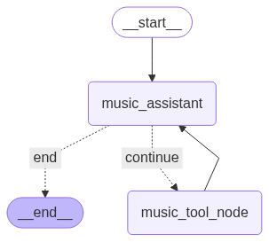

```python
from langgraph.graph import StateGraph, START, END # Core LangGraph classes and special node names
from utils import show_graph # Utility function to visualize the graph (assumed to be in a utils.py file)

# Initialize a StateGraph with our defined `State` schema.
# This tells LangGraph how the data will flow and be managed within the graph.
music_workflow = StateGraph(State)

# Add the 'music_assistant' node to the graph.
# This node is responsible for the LLM's reasoning and generating tool calls or final responses.
music_workflow.add_node("music_assistant", music_assistant)

# Add the 'music_tool_node' to the graph.
# This node is responsible for executing the tools when requested by the LLM.
music_workflow.add_node("music_tool_node", music_tool_node)


# Define the starting point of the graph.
# All queries will initially enter the 'music_assistant' node.
music_workflow.add_edge(START, "music_assistant")

# Add a conditional edge from 'music_assistant'.
# The `should_continue` function will be called to determine the next node.
music_workflow.add_conditional_edges(
    "music_assistant", # Source node
    should_continue,   # Conditional function to call
    {
        # If `should_continue` returns "continue", route to `music_tool_node`.
        "continue": "music_tool_node",
        # If `should_continue` returns "end", terminate the graph execution.
        "end": END,
    },
)

# Add a normal edge from 'music_tool_node' back to 'music_assistant'.
# After a tool is executed, the result is fed back to the LLM for further reasoning
# or to formulate a final response (ReAct loop).
music_workflow.add_edge("music_tool_node", "music_assistant")

# Compile the graph into a runnable object.
# `name`: A unique identifier for this compiled graph (useful for debugging and logging).
# `checkpointer`: The short-term memory mechanism (MemorySaver) for thread-specific state.
# `store`: The long-term memory mechanism (InMemoryStore) for persistent user data.
music_catalog_subagent = music_workflow.compile(name="music_catalog_subagent", checkpointer=checkpointer, store = in_memory_store)

# Display a visualization of the compiled graph.
show_graph(music_catalog_subagent)
```

#### Testing the Music Catalog Sub-Agent

Now that our first ReAct sub-agent is compiled, let's test its functionality. We'll simulate a customer inquiry and observe how the agent processes it, potentially invoking tools and providing a response.

Key elements in testing:

- `uuid.uuid4()`: Generates a unique thread ID for each conversation. This is crucial for the checkpointer to maintain separate states for different conversations.
  - In a real application, this `thread_id` would typically correspond to a user session or a unique conversation identifier.
- `config`: A dictionary passed to the `invoke` method, containing configurable parameters like the `thread_id`. The checkpointer uses this `thread_id` to load and save the correct state.
- `invoke()`: Starts the execution of the LangGraph. It takes the initial input (`messages` in our `State`) and the `config`.
- `pretty_print()`: A utility method (assuming it's defined for `AnyMessage` or similar) to display the messages in a readable format, showing roles and content.

```python
import uuid # Module for generating unique identifiers

# Generate a unique thread ID for this conversation.
# This ensures that the conversation state is isolated and can be resumed later.
thread_id = uuid.uuid4()

# Define the customer's question.
question = "I like the Rolling Stones. What songs do you recommend by them or by other artists that I might like?"

# Create the configuration dictionary for invoking the graph.
# The `thread_id` is essential for the checkpointer to manage state.
config = {"configurable": {"thread_id": thread_id}}

# Invoke the `music_catalog_subagent` with the initial human message and configuration.
# The `invoke` method runs the graph to completion and returns the final state.
result = music_catalog_subagent.invoke({"messages": [HumanMessage(content=question)]}, config=config)

# Iterate through the messages in the final state and print them for observation.
# `pretty_print()` provides a formatted output of the message content and role.
for message in result["messages"]:
   message.pretty_print()
```

```
================================ Human Message =================================

I like the Rolling Stones. What songs do you recommend by them or by other artists that I might like?
================================== Ai Message ==================================
Tool Calls:
  get_tracks_by_artist (chatcmpl-tool-5a7dbb7694e3402da7e9119ce0e12e6f)
 Call ID: chatcmpl-tool-5a7dbb7694e3402da7e9119ce0e12e6f
  Args:
    artist: The Rolling Stones
================================= Tool Message =================================
Name: get_tracks_by_artist

[{'SongName': 'Time Is On My Side', 'ArtistName': 'The Rolling Stones'}, {'SongName': 'Heart Of Stone', 'ArtistName': 'The Rolling Stones'}, {'SongName': 'Play With Fire', 'ArtistName': 'The Rolling Stones'}, {'SongName': 'Satisfaction', 'ArtistName': 'The Rolling Stones'}, {'SongName': 'As Tears Go…
================================== Ai Message ==================================

The Rolling Stones have a vast and diverse discography, and here are some songs that you might enjoy:

1. Time Is On My Side
2. Heart Of Stone
3. Play With Fire
4. Satisfaction
5. As Tears Go By
6. Get Off Of My Cloud
7. Mother's Little Helper
8. 19th Nervous Breakdown
9. Paint It Black
10. Under My Thumb
11. Ruby Tuesday
12. Let's Spend The Night Together
13. Intro
14. You Got Me Rocking
15. Gimmie Shelters
16. Flip The Switch
17. Memory Motel
18. Corinna
19. Saint Of Me
20. Wainting On A Friend
21. Sister Morphine
22. Live With Me
23. Respectable
24. Thief In The Night
25. The Last Time
26. Out Of Control
27. Love Is Strong
28. You Got Me Rocking
29. Sparks Will Fly
30. The Worst
31. New Faces
32. Moon Is Up
33. Out Of Tears
34. I Go Wild
35. Brand New Car
36. Sweethearts Together
37. Suck On The Jugular
38. Blinded By Rainbows
39. Baby Break It Down
40. Thru And Thru
41. Mean Disposition

These songs showcase the band's ability to blend different styles and create unique sounds, and are a great representation of their musical talent and creativity.
```

### 1.2. Building ReAct Agent using LangGraph Pre-built: The Invoice Information Sub-Agent

While building agents from scratch provides deep understanding, LangGraph also offers **pre-built libraries** for common architectures. These pre-built solutions allow for rapid development of standard agent patterns like ReAct, saving significant boilerplate code.

You can find a full list of available pre-built libraries here: [LangGraph Pre-built Libraries](https://langchain-ai.github.io/langgraph/prebuilt/#available-libraries)

In this section, we will demonstrate how to create our second sub-agent, the **Invoice Information Sub-Agent**, using the `create_react_agent` pre-built utility. This agent will be responsible for handling all customer inquiries related to invoices and past purchases.

[figure not shown]

#### Defining Tools and Prompt for Invoice Sub-Agent

Similar to our music sub-agent, the invoice sub-agent requires its own set of specialized tools and a tailored prompt. These tools will interact with the Chinook database to retrieve invoice-specific information.

Each tool is designed to answer a specific type of query a customer might have about their invoices. The prompts will guide the LLM to understand its role and effectively use these tools.

```python
from langchain_core.tools import tool # Import the tool decorator again

@tool
def get_invoices_by_customer_sorted_by_date(customer_id: str) -> list[dict]:
    """
    Look up all invoices for a customer using their ID.
    The invoices are sorted in descending order by invoice date, which helps when the customer wants to view their most recent/oldest invoice, or if
    they want to view invoices within a specific date range.

    Args:
        customer_id (str): customer_id, which serves as the identifier.

    Returns:
        list[dict]: A list of invoices for the customer.
    """
    # Executes a SQL query to retrieve all invoice details for a given customer ID,
    # ordered by invoice date in descending order (most recent first).
    return db.run(f"SELECT * FROM Invoice WHERE CustomerId = {customer_id} ORDER BY InvoiceDate DESC;")


@tool
def get_invoices_sorted_by_unit_price(customer_id: str) -> list[dict]:
    """
    Use this tool when the customer wants to know the details of one of their invoices based on the unit price/cost of the invoice.
    This tool looks up all invoices for a customer, and sorts the unit price from highest to lowest. In order to find the invoice associated with the customer,
    we need to know the customer ID.

    Args:
        customer_id (str): customer_id, which serves as the identifier.

    Returns:
        list[dict]: A list of invoices sorted by unit price.
    """
    # Executes a SQL query to retrieve invoice details along with the unit price of items in those invoices,
    # for a given customer ID, ordered by unit price in descending order (highest unit price first).
    query = f"""
        SELECT Invoice.*, InvoiceLine.UnitPrice
        FROM Invoice
        JOIN InvoiceLine ON Invoice.InvoiceId = InvoiceLine.InvoiceId
        WHERE Invoice.CustomerId = {customer_id}
        ORDER BY InvoiceLine.UnitPrice DESC;
    """
    return db.run(query)


@tool
def get_employee_by_invoice_and_customer(invoice_id: str, customer_id: str) -> dict:
    """
    This tool will take in an invoice ID and a customer ID and return the employee information associated with the invoice.

    Args:
        invoice_id (int): The ID of the specific invoice.
        customer_id (str): customer_id, which serves as the identifier.

    Returns:
        dict: Information about the employee associated with the invoice.
    """

    # Executes a SQL query to find the employee associated with a specific invoice and customer.
    # It joins Employee, Customer, and Invoice tables to retrieve employee first name, title, and email.
    query = f"""
        SELECT Employee.FirstName, Employee.Title, Employee.Email
        FROM Employee
        JOIN Customer ON Customer.SupportRepId = Employee.EmployeeId
        JOIN Invoice ON Invoice.CustomerId = Customer.CustomerId
        WHERE Invoice.InvoiceId = ({invoice_id}) AND Invoice.CustomerId = ({customer_id});
    """

    employee_info = db.run(query, include_columns=True)

    # Checks if any employee information was found.
    if not employee_info:
        return f"No employee found for invoice ID {invoice_id} and customer identifier {customer_id}."
    return employee_info

# Aggregate all invoice-related tools into a list.
invoice_tools = [get_invoices_by_customer_sorted_by_date, get_invoices_sorted_by_unit_price, get_employee_by_invoice_and_customer]
```

```python
# Define the system prompt for the invoice information sub-agent.
# This prompt sets the persona and core responsibilities for the LLM within this sub-agent's domain.
# It explicitly lists the tools available to this agent and provides guidelines for their use.
invoice_subagent_prompt = """
    You are a subagent among a team of assistants. You are specialized for retrieving and processing invoice information. You are routed for invoice-related portion of the questions, so only respond to them..

    You have access to three tools. These tools enable you to retrieve and process invoice information from the database. Here are the tools:
    - get_invoices_by_customer_sorted_by_date: This tool retrieves all invoices for a customer, sorted by invoice date.
    - get_invoices_sorted_by_unit_price: This tool retrieves all invoices for a customer, sorted by unit price.
    - get_employee_by_invoice_and_customer: This tool retrieves the employee information associated with an invoice and a customer.

    If you are unable to retrieve the invoice information, inform the customer you are unable to retrieve the information, and ask if they would like to search for something else.

    CORE RESPONSIBILITIES:
    - Retrieve and process invoice information from the database
    - Provide detailed information about invoices, including customer details, invoice dates, total amounts, employees associated with the invoice, etc. when the customer asks for it.
    - Always maintain a professional, friendly, and patient demeanor

    You may have additional context that you should use to help answer the customer's query. It will be provided to you below:
    """
```

#### Using the Pre-built Library: `create_react_agent`

Now, let's assemble our invoice sub-agent using LangGraph's `create_react_agent` function. This utility abstracts away the node and edge definitions for a standard ReAct loop, allowing us to quickly create a runnable agent.

The `create_react_agent` function handles:

- Binding the provided `tools` to the `model`.
- Setting up the LLM (`model`) as the reasoning node.
- Setting up a `ToolNode` to execute the tools.
- Defining the conditional logic (edges) to loop between the LLM and the tools until a final answer is produced or a recursion limit is reached.

We provide it with:

- `model`: The LLM to use (our `ChatOpenAI` instance).
- `tools`: The list of functions available to the agent.
- `name`: A unique name for this agent (useful for identification in a multi-agent system).
- `prompt`: The system prompt to guide the LLM's behavior.
- `state_schema`: The `State` class we defined, ensuring consistency across agents.
- `checkpointer` and `store`: Our memory mechanisms for thread-level state and long-term user data.

```python
from langgraph.prebuilt import create_react_agent # Import the pre-built ReAct agent creator

# Define the invoice information subagent using the pre-built `create_react_agent`.
# This function internally sets up the nodes (LLM and ToolNode) and edges for a ReAct loop.
invoice_information_subagent = create_react_agent(
    llm,                          # The language model to use for reasoning
    tools=invoice_tools,            # The list of tools available to this agent
    name="invoice_information_subagent", # A unique name for this agent within the graph
    prompt=invoice_subagent_prompt, # The system prompt for this agent's persona and instructions
    state_schema=State,             # The shared state schema for the graph
    checkpointer=checkpointer,      # The checkpointer for short-term (thread-level) memory
    store = in_memory_store         # The in-memory store for long-term user data
)
```

#### Testing the Invoice Information Sub-Agent!

Let's test our newly created invoice sub-agent to ensure it correctly processes queries related to invoices and utilizes its specific tools.

```python
thread_id = uuid.uuid4() # Generate a new unique thread ID for this test conversation.

# Define a sample question for the invoice sub-agent.
question = "My customer id is 1. What was my most recent invoice, and who was the employee that helped me with it?"

# Set up the configuration with the thread ID.
config = {"configurable": {"thread_id": thread_id}}

# Invoke the invoice sub-agent with the question and configuration.
result = invoice_information_subagent.invoke({"messages": [HumanMessage(content=question)]}, config=config)

# Print the conversation history from the result for verification.
for message in result["messages"]:
    message.pretty_print()
```

```
================================ Human Message =================================

My customer id is 1. What was my most recent invoice, and who was the employee that helped me with it?
================================== Ai Message ==================================
Name: invoice_information_subagent
Tool Calls:
  get_invoices_by_customer_sorted_by_date (chatcmpl-tool-a9da98e581d540c9a14031ac0beafdc5)
 Call ID: chatcmpl-tool-a9da98e581d540c9a14031ac0beafdc5
  Args:
    customer_id: 1
================================= Tool Message =================================
Name: get_invoices_by_customer_sorted_by_date

[(382, 1, '2025-08-07 00:00:00', 'Av. Brigadeiro Faria Lima, 2170', 'São José dos Campos', 'SP', 'Brazil', '12227-000', 8.91), (327, 1, '2024-12-07 00:00:00', 'Av. Brigadeiro Faria Lima, 2170', 'São José dos Campos', 'SP', 'Brazil', '12227-000', 13.86), (316, 1, '2024-10-27 00:00:00', 'Av. Brigadeir…
================================== Ai Message ==================================
Name: invoice_information_subagent
Tool Calls:
  get_employee_by_invoice_and_customer (chatcmpl-tool-a34101143f6f4a3d9a370acaa8b9c879)
 Call ID: chatcmpl-tool-a34101143f6f4a3d9a370acaa8b9c879
  Args:
    invoice_id: 382
    customer_id: 1
================================= Tool Message =================================
Name: get_employee_by_invoice_and_customer

[{'FirstName': 'Jane', 'Title': 'Sales Support Agent', 'Email': 'jane@chinookcorp.com'}]
================================== Ai Message ==================================
Name: invoice_information_subagent

The most recent invoice for customer ID 1 is invoice number 382, dated '2025-08-07 00:00:00'. The employee who helped with this invoice is Jane, a Sales Support Agent, and her email address is jane@chinookcorp.com.
```

## Part 2: Building Multi-Agent Architecture (Supervisor)

Now that we have two specialized sub-agents—one for music catalog inquiries and another for invoice information—the next logical step is to ensure that customer queries are routed to the appropriate agent. This is where a **supervisor agent** comes into play.

The supervisor acts as a central coordinator, overseeing the workflow and intelligently invoking the most relevant sub-agent based on the customer's query. This eliminates the need for each sub-agent to understand all possible query types, allowing them to remain focused on their core expertise.

### The Supervisor Role

[figure not shown]

LangGraph offers a pre-built `create_supervisor` utility, which simplifies the creation of such a routing mechanism. This function sets up a powerful LLM-based router that leverages the descriptions and capabilities of the sub-agents to make routing decisions.

First, we will create a set of instructions for our supervisor. This prompt defines the supervisor's persona, its role as a planner and router, and the capabilities of the sub-agents it oversees.

```python
supervisor_prompt = """You are an expert customer support assistant for a digital music store.
You are dedicated to providing exceptional service and ensuring customer queries are answered thoroughly.
You have a team of subagents that you can use to help answer queries from customers.
Your primary role is to serve as a supervisor/planner for this multi-agent team that helps answer queries from customers.

Your team is composed of two subagents that you can use to help answer the customer's request:
1. music_catalog_information_subagent: this subagent has access to user's saved music preferences. It can also retrieve information about the digital music store's music
catalog (albums, tracks, songs, etc.) from the database.
3. invoice_information_subagent: this subagent is able to retrieve information about a customer's past purchases or invoices
from the database.

Based on the existing steps that have been taken in the messages, your role is to generate the next subagent that needs to be called.
This could be one step in an inquiry that needs multiple sub-agent calls. """
```

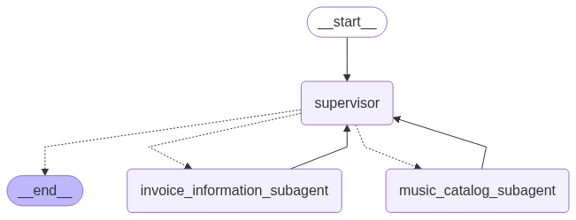

```python
from langgraph_supervisor import create_supervisor # Import the pre-built supervisor creator

# Create the supervisor workflow using the `create_supervisor` utility.
# This function dynamically sets up the graph to route between the provided agents.
supervisor_prebuilt_workflow = create_supervisor(
    agents=[invoice_information_subagent, music_catalog_subagent], # List of sub-agents the supervisor can route to
    output_mode="last_message", # Specifies that the supervisor should output only the last message from the routed agent.
                                # Alternative is "full_history" to get all messages from the sub-agent.
    model=llm,                # The LLM to act as the supervisor (for routing decisions).
    prompt=(supervisor_prompt), # The system prompt guiding the supervisor's behavior.
    state_schema=State          # The shared state schema for the entire multi-agent graph.
)

# Compile the supervisor workflow into a runnable object.
# This makes it ready for invocation and integrates it with our memory systems.
supervisor_prebuilt = supervisor_prebuilt_workflow.compile(name="music_catalog_subagent", checkpointer=checkpointer, store=in_memory_store)

# Display a visualization of the compiled supervisor graph.
# Notice how the supervisor acts as the central hub, directing traffic to its sub-agents.
show_graph(supervisor_prebuilt)
```

#### Testing the Multi-Agent Supervisor

```python
thread_id = uuid.uuid4() # Generate a fresh thread ID for this conversation.

# Define a question that involves both invoice and music information.
question = "My customer ID is 1. How much was my most recent purchase? What albums do you have by U2?"

# Configure the invocation with the thread ID.
config = {"configurable": {"thread_id": thread_id}}

# Invoke the `supervisor_prebuilt` graph with the human message.
# The supervisor will analyze the question, route it to the appropriate sub-agent(s),
# and return the final response from the last active agent.
result = supervisor_prebuilt.invoke({"messages": [HumanMessage(content=question)]}, config=config)

# Print the messages from the resulting state to see the conversation flow and final answer.
for message in result["messages"]:
    message.pretty_print()
```

```
================================ Human Message =================================

My customer ID is 1. How much was my most recent purchase? What albums do you have by U2?
================================== Ai Message ==================================
Name: supervisor
Tool Calls:
  transfer_to_invoice_information_subagent (chatcmpl-tool-27d6552a6b7d4cb891de174b2b58cd59)
 Call ID: chatcmpl-tool-27d6552a6b7d4cb891de174b2b58cd59
  Args:
================================= Tool Message =================================
Name: transfer_to_invoice_information_subagent

Successfully transferred to invoice_information_subagent
================================== Ai Message ==================================
Name: invoice_information_subagent

Your most recent purchase was on '2025-08-07 00:00:00' and the total amount was $8.91. I am not able to tell you what albums we have by U2. Would you like to search for something else?
================================== Ai Message ==================================
Name: invoice_information_subagent

Transferring back to supervisor
Tool Calls:
  transfer_back_to_supervisor (3aeacc24-4511-4cb9-ad2e-52255e779732)
 Call ID: 3aeacc24-4511-4cb9-ad2e-52255e779732
  Args:
================================= Tool Message =================================
Name: transfer_back_to_supervisor

Successfully transferred back to supervisor
================================== Ai Message ==================================
Name: supervisor
Tool Calls:
  transfer_to_music_catalog_information_subagent (chatcmpl-tool-75c5eef3fe334c6cab841d0612574134)
 Call ID: chatcmpl-tool-75c5eef3fe334c6cab841d0612574134
  Args:
================================= Tool Message =================================
Name: transfer_to_music_catalog_information_subagent

Error: transfer_to_music_catalog_information_subagent is not a valid tool, try one of [transfer_to_music_catalog_subagent, transfer_to_invoice_information_subagent].
================================== Ai Message ==================================
Name: supervisor

The correct function name is "transfer_to_music_catalog_subagent". Here is the corrected response:

{"name": "transfer_to_music_catalog_subagent", "parameters": {}}
```

## Part 3: Adding Customer Verification through Human-in-the-Loop

Currently, our agent assumes we have the `customer_id` readily available or directly provided in the initial query. In a realistic customer support scenario, we often need to **first verify the customer's identity** before processing sensitive inquiries like invoice details. This verification might involve asking the user for an identifier (e.g., email, phone, customer ID) and then looking it up in the database.

To implement this, we'll introduce a **human-in-the-loop** component. This means the graph can *pause* execution and wait for additional input from the user (or a human agent) before proceeding. LangGraph's `interrupt` mechanism is perfect for this.

[figure not shown]

In this step, we will add two new nodes to our workflow:

- **`verify_info` node**: This node will attempt to extract a customer identifier from the user's input and verify it against our database. If found, it updates the `customer_id` in the graph state. If not found or not provided, it prompts the user for the information.
- **`human_input` node**: This is a simple node that explicitly triggers an `interrupt`, pausing the graph execution until the user provides the necessary information to resume.

We'll also leverage LangChain's structured output capabilities to reliably parse user input for identifiers using Pydantic schemas.

```python
from pydantic import BaseModel, Field # Pydantic for defining data schemas and field validation

# Define a Pydantic BaseModel to structure the expected user input for account information.
# This helps the LLM to parse specific entities (identifier) from free-form text.
class UserInput(BaseModel):
    """Schema for parsing user-provided account information."""
    # `identifier` field: Expects a string, with a description for the LLM to understand its purpose.
    identifier: str = Field(description = "Identifier, which can be a customer ID, email, or phone number.")

# Bind the Pydantic schema to our LLM using `with_structured_output`.
# This forces the LLM to generate output that conforms to the `UserInput` schema, making parsing reliable.
structured_llm = llm.with_structured_output(schema=UserInput)

# Define a system prompt specifically for the structured LLM.
# This prompt instructs the LLM on how to extract the customer identifier from messages.
structured_system_prompt = """You are a customer service representative responsible for extracting customer identifier.\n
Only extract the customer's account information from the message history.
If they haven't provided the information yet, return an empty string for the file"""
```

```python
from typing import Optional # For type hinting optional values

# Helper function to retrieve a customer ID from various identifiers (ID, phone, email).
def get_customer_id_from_identifier(identifier: str) -> Optional[int]:
    """
    Retrieve Customer ID using an identifier, which can be a customer ID, email, or phone number.

    Args:
        identifier (str): The identifier can be customer ID, email, or phone.

    Returns:
        Optional[int]: The CustomerId if found, otherwise None.
    """
    # Check if the identifier is purely numeric, indicating a direct customer ID.
    if identifier.isdigit():
        return int(identifier)

    # Check if the identifier starts with '+', suggesting a phone number.
    elif identifier[0] == "+":
        query = f"SELECT CustomerId FROM Customer WHERE Phone = '{identifier}';"
        result = db.run(query)
        formatted_result = ast.literal_eval(result) # Safely evaluate string to list/tuple
        if formatted_result:
            return formatted_result[0][0] # Return the first CustomerId found

    # Check if the identifier contains '@', suggesting an email address.
    elif "@" in identifier:
        query = f"SELECT CustomerId FROM Customer WHERE Email = '{identifier}';"
        result = db.run(query)
        formatted_result = ast.literal_eval(result)
        if formatted_result:
            return formatted_result[0][0] # Return the first CustomerId found

    # If no matching identifier type is found or no ID is retrieved, return None.
    return None
```

```python
# Define the `verify_info` node function.
# This node is responsible for verifying the customer's identity based on their input.
def verify_info(state: State, config: RunnableConfig):
    """Verify the customer's account by parsing their input and matching it with the database."""

    # Check if a customer_id is already present in the state.
    # If it is, verification is complete, and the node does nothing (passes).
    if state.get("customer_id") is None:
        # System instructions for the verification LLM.
        system_instructions = """You are a music store agent, where you are trying to verify the customer identity
        as the first step of the customer support process.
        Only after their account is verified, you would be able to support them on resolving the issue.
        In order to verify their identity, one of their customer ID, email, or phone number needs to be provided.
        If the customer has not provided the information yet, please ask them for it.
        If they have provided the identifier but cannot be found, please ask them to revise it."""

        # Get the most recent user message from the state.
        user_input = state["messages"][-1]

        # Use the structured LLM to parse the user's input for an identifier.
        # It combines the structured system prompt with the user's message.
        parsed_info = structured_llm.invoke([SystemMessage(content=structured_system_prompt)] + [user_input])

        # Extract the identified identifier string.
        identifier = parsed_info.identifier

        customer_id = "" # Initialize customer_id as an empty string.
        # Attempt to find the customer ID in the database using the helper function.
        if (identifier):
            customer_id = get_customer_id_from_identifier(identifier)

        # If a valid customer_id was found,
        if customer_id != "":
            # Create a system message confirming verification.
            intent_message = SystemMessage(
                content= f"Thank you for providing your information! I was able to verify your account with customer id {customer_id}."
            )
            # Update the state with the found customer_id and the confirmation message.
            return {
                  "customer_id": customer_id,
                  "messages" : [intent_message]
                  }
        # If no customer_id was found or provided,
        else:
          # Invoke the base LLM with instructions to prompt the user for their identifier or revise it.
          response = llm.invoke([SystemMessage(content=system_instructions)]+state['messages'])
          # Update the state with the LLM's response (the prompt for user input).
          return {"messages": [response]}

    else:
        # If `customer_id` is already in state, this node does nothing.
        # This `pass` implies that the graph will simply proceed to the next edge,
        # as defined in the graph compilation.
        pass
```

Now, let's create our `human_input` node. This node is designed to trigger an `interrupt` in the graph. When an interrupt occurs, the graph pauses, and control is returned to the caller (e.g., the notebook or an application). The caller can then choose to resume the graph, optionally providing new input.

This is how we implement the human-in-the-loop interaction for customer verification: the graph asks for an identifier, pauses, and waits for the user to provide it.

```python
from langgraph.types import interrupt # Import the `interrupt` function for pausing graph execution

# Define the `human_input` node function.
# This node serves as a placeholder to signal that human intervention is required.
def human_input(state: State, config: RunnableConfig):
    """ No-op node that should be interrupted on """
    # `interrupt("Please provide input.")` pauses the graph execution.
    # The string message is passed as a reason for the interrupt.
    # When the graph is resumed, the new input will be stored in `user_input`.
    user_input = interrupt("Please provide input.")

    # The new user input (after resume) is then added to the messages in the state.
    return {"messages": [user_input]}
```

Let's put this together! We'll integrate the `verify_info` and `human_input` nodes into a new graph structure. The flow will be:

1. **`START`** -> **`verify_info`**: All incoming queries first attempt to verify the customer.
2. **`verify_info` (Conditional Edge)**:
   - If `customer_id` is *not* found (meaning verification failed or input is pending), it routes to **`human_input`**.
   - If `customer_id` *is* found (meaning verification succeeded), it routes to the **`supervisor`**.
3. **`human_input`** -> **`verify_info`**: After the user provides input to resume the graph, it routes back to `verify_info` to re-attempt verification with the new input.
4. **`supervisor`** -> **`END`**: Once the main query is handled by the supervisor and its sub-agents, the graph ends.

This setup ensures that customer identity is verified before any other action, and gracefully handles cases where identity needs to be provided or re-attempted.

```python
# Define the conditional edge function for `verify_info`.
# This function checks if a `customer_id` has been successfully set in the state.
def should_interrupt(state: State, config: RunnableConfig):
    # If `customer_id` is present, it means verification was successful or already done, so continue.
    if state.get("customer_id") is not None:
        return "continue"
    # Otherwise, it means customer ID is missing or couldn't be verified, so interrupt for human input.
    else:
        return "interrupt"
```

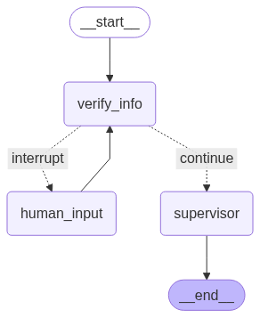

```python
# Initialize a new StateGraph for our multi-agent system with human-in-the-loop verification.
multi_agent_verify = StateGraph(State)

# Add the `verify_info` node for customer identity verification.
multi_agent_verify.add_node("verify_info", verify_info)

# Add the `human_input` node, which triggers an interrupt to get user input.
multi_agent_verify.add_node("human_input", human_input)

# Add the `supervisor` node, which orchestrates the sub-agents for query handling.
multi_agent_verify.add_node("supervisor", supervisor_prebuilt)

# Define the entry point: all interactions start with customer verification.
multi_agent_verify.add_edge(START, "verify_info")

# Define the conditional routing after `verify_info`.
# `should_interrupt` decides whether to continue to the supervisor or prompt for human input.
multi_agent_verify.add_conditional_edges(
    "verify_info",     # Source node
    should_interrupt,  # Conditional function
    {
        # If verification is successful, continue to the main supervisor agent.
        "continue": "supervisor",
        # If verification is needed (or failed), route to `human_input` to prompt the user.
        "interrupt": "human_input",
    },
)

# After `human_input` (once resumed), loop back to `verify_info` to try verification again.
multi_agent_verify.add_edge("human_input", "verify_info")

# The supervisor is the final processing stage before the graph ends.
multi_agent_verify.add_edge("supervisor", END)

# Compile the complete graph, integrating all nodes and edges with our memory systems.
multi_agent_verify_graph = multi_agent_verify.compile(name="multi_agent_verify", checkpointer=checkpointer, store=in_memory_store)

# Display the visualization of the new graph.
show_graph(multi_agent_verify_graph)
```